# Relación Minutos

### **⚛️ A. Titulo: Proyecto 1 – Relación Minutos Ingreso**

### **⚛️ B. Integrantes**

Jiliar Antonio Silgado Cardona

### **⚛️ C. Nucleo Problemico**

#### **⭕️ Introducción**

En una empresa con una base de clientes extensa, analizar el comportamiento de cada cliente de manera individual no es eficiente ni práctico. Gracias a la programación y al análisis de datos, es posible identificar patrones y tendencias de manera rápida y precisa, permitiendo descubrir relaciones entre variables que no son evidentes a simple vista. Este enfoque facilita la toma de decisiones informadas y el desarrollo de estrategias que optimicen los productos y las campañas publicitarias, con el objetivo de mejorar tanto la experiencia del cliente como el rendimiento empresarial.

#### **⭕️ Núcleo Problémico**

Dado el gran volumen de datos generados por los clientes, la empresa enfrenta el reto de identificar las relaciones clave entre el uso de sus servicios y los ingresos generados. En particular, se requiere analizar si existe una conexión significativa entre el tiempo que los clientes utilizan los servicios (medido en minutos) y los ingresos que aportan a la empresa. Sin contar con esta información precisa, resulta difícil desarrollar estrategias efectivas para mejorar los productos, diseñar campañas publicitarias personalizadas y tomar decisiones acertadas que impulsen el crecimiento del negocio. La falta de claridad en estas relaciones podría llevar a decisiones basadas en suposiciones, afectando negativamente el retorno de inversión y la satisfacción de los clientes.

#### **⭕️ Pregunta Problemica**

¿Existe una relación significativa entre el total de minutos utilizados por los clientes y los ingresos totales generados por ellos, y se puede afirmar que a medida que aumentan los ingresos de los clientes, también incrementa el uso de minutos, o bien, es posible que la relación sea inversa o nula?

### **🔍 1. Exploración de los datos**

#### **⭕️ Introducción a la Fase de Exploración de Datos**

En esta fase inicial del análisis de datos, se realiza una exploración preliminar del conjunto de datos para comprender su estructura y características básicas. Esta etapa es crucial para identificar los aspectos fundamentales del dataset y preparar el terreno para un análisis más profundo.

Durante la exploración, se utilizan diversas instrucciones para obtener una visión general del conjunto de datos:

### **⭕️ Entendimiento de los datos**

| Variable | Definición | Descripción | Valores |
| --- | --- | --- | --- |
| totrev | Ingresos del cliente | Representa los ingresos totales generados por cada cliente, posiblemente derivados de sus actividades o consumo de servicios. | Número real |
| totmou | Total de minutos usados por el cliente | Indica el total de minutos utilizados por el cliente, reflejando su nivel de actividad en el uso de un servicio o producto, como tiempo en llamadas u otro consumo basado en minutos. | Número entero |
| creditcd | Indicador de tarjeta de crédito | Un indicador binario que muestra si el cliente posee una tarjeta de crédito (1 para clientes con tarjeta de crédito y 0 para aquellos que no la tienen). | Y (Sí), N (No) |
| eqpdays | Número de días (antigüedad) del equipo actual | Refleja la antigüedad del equipo actual en días, proporcionando una idea de cuánto tiempo ha estado el cliente utilizando su dispositivo actual o tecnología asociada. | Número entero |
| Customer_ID | Identificador único del cliente | Un identificador numérico único para cada cliente en la base de datos, que permite diferenciar los registros individuales. | Número entero |

Esta base de datos es útil para analizar el comportamiento financiero y de consumo de los clientes, permitiendo entender patrones de ingresos, tiempo de uso de servicios, tenencia de tarjetas de crédito y la antigüedad de sus equipos tecnológicos.

```python
# Cargar librerías
import seaborn as sns
import pandas as pd
import numpy as np
import seaborn as sns
import matplotlib.pyplot as plt

#Lectura de origen de datos:
df = pd.read_csv('../Datos/Credito_dias.csv')
```

```python
# Información de Dataframe
print("Información general del DataFrame:\n")
df.info()
```

```
Información general del DataFrame:

<class 'pandas.core.frame.DataFrame'>
RangeIndex: 10000 entries, 0 to 9999
Data columns (total 5 columns):
 #   Column       Non-Null Count  Dtype
---  ------       --------------  -----
 0   totmou       10000 non-null  float64
 1   totrev       10000 non-null  float64
 2   creditcd     9848 non-null   object
 3   eqpdays      10000 non-null  int64
 4   Customer_ID  10000 non-null  int64
dtypes: float64(2), int64(2), object(1)
memory usage: 390.8+ KB
```

### **⭕️ Diccionario de datos**

Este diccionario de datos proporciona una descripción detallada de las columnas del dataframe obtenido del archivo `Credito_dias.csv`. Cada columna está detallada con su tipo de dato (`Dtype`), una breve descripción del tipo de dato (`Descripción Dtype`), el tamaño en bytes ocupado por el tipo de dato (`Tamaño en Bytes`), y una descripción de los datos representados en esa columna.

El propósito de este diccionario es facilitar la comprensión de la estructura del conjunto de datos y ayudar en el análisis y la manipulación de la información.

**Descripción de las Columnas en** `Credito_dias.csv`

| Column | Dtype | Description Dtype | Tamaño en Bytes | Descripción |
| --- | --- | --- | --- | --- |
| totmou | float64 | Número decimal | 8 | Total de minutos usados por el cliente |
| totrev | float64 | Número decimal | 8 | Ingresos totales generados por el cliente |
| creditcd | object | Texto | Variable | Indicador de tarjeta de crédito (Y: Sí, N: No) |
| eqpdays | int64 | Número entero | 8 | Número de días de antigüedad del equipo actual del cliente |
| Customer_ID | int64 | Número entero | 8 | Identificador único del cliente |

### **⭕️ Dimensiones del Dataframe (Filas x Columnas)**

```python
#Forma del dataframe
print(df.shape)
```

```
(10000, 5)
```

#### **⭕️ Primeras filas del DataFrame**

```python
# Primeros registros
print(df.head())
```

```
    totmou   totrev creditcd  eqpdays  Customer_ID
0   7269.0   906.58        Y      371      1082423
1  13552.0  1172.25        N       83      1069232
2   4152.0   577.39        Y      675      1031705
3   1863.0   294.26        Y      218      1089806
4   4155.0   433.16        N      222      1076695
```

#### **⭕️ Últimas filas del DataFrame**

```python
# ultimos registros
print(df.tail())
```

```
      totmou   totrev creditcd  eqpdays  Customer_ID
9995  2570.0   484.31        Y      611      1027614
9996  2105.0   583.36        Y     1243      1098422
9997  3690.0   294.29        Y      212      1096497
9998  3333.0   233.08        Y      290      1087248
9999  5025.0  1436.49        Y     1029      1099003
```

#### **⭕️ Tamaño total del DataFrame en términos de número de filas**

```python
# total de registros
total_size = len(df)
print(f'Tamaño (Número de Filas): {total_size}')
```

```
Tamaño (Número de Filas): 10000
```

#### **⭕️ Uso de memoria por columna**

```python
# mostrar el tamaño de la memoria utilizada por el DataFrame
print("Memoria utilizada por el DataFrame (bytes):\n")
print(df.memory_usage(deep=True))
```

```
Memoria utilizada por el DataFrame (bytes):

Index             132
totmou          80000
totrev          80000
creditcd       497264
eqpdays         80000
Customer_ID     80000
dtype: int64
```

#### **⭕️ Columnas (Variables) en Dataframe**

```python
# nombres de las columnas
print("\nNombres de las columnas:")
print(df.columns)
```

```
Nombres de las columnas:
Index(['totmou', 'totrev', 'creditcd', 'eqpdays', 'Customer_ID'], dtype='object')
```

#### **⭕️ Número Total de Variables**

```python
# Número total de variables que contiene la base de datos.
num_columnas = df.shape[1]
print(f'Número de variables (columnas): {num_columnas}')
```

```
Número de variables (columnas): 5
```

#### **⭕️ Variables con datos faltantes, Porcentaje total de valores faltantes en la base de datos.**

```python
import json

def valores_faltantes_por_columna(df):
    # Escribir las variables que tienen datos faltantes, además, proporcionar el porcentaje total de valores faltantes en la base de datos.
    # Paso 1: Encontrar columnas con valores faltantes
    faltantes_por_columna = df.isnull().sum()

    # Paso 2: Filtrar columnas que tienen valores faltantes
    data1 = faltantes_por_columna[faltantes_por_columna > 0]
    variables_con_faltantes = data1.to_dict()

    print('\nCant. valores faltantes por columna:',
          json.dumps(variables_con_faltantes, indent=4),
          sep="\n")

    # Paso 3: Calcular el porcentaje de valores faltantes por columna
    data = (data1 / len(df)) * 100
    data = data.to_dict()
    porcentaje_faltantes_por_columna = {key: f'{value:.2f}%' for key, value in data.items()}

    # Paso 4: Calcular el porcentaje total de valores faltantes en el DataFrame
    porcentaje_total_faltantes = (df.isnull().sum().sum() / df.size) * 100
    porcentaje_total_no_faltantes = (df.notnull().sum().sum() / df.size) * 100

    # Resultados
    print('\n% valores faltantes por columna:', f'{json.dumps(porcentaje_faltantes_por_columna, indent=4)}', sep="\n")

    print(f"\nPorcentaje total de valores faltantes en la base de datos: {porcentaje_total_faltantes:.2f}%")
    print(f"Porcentaje total de valores en la base de datos: {porcentaje_total_no_faltantes:.2f}%")

valores_faltantes_por_columna(df)
```

[output not shown]

#### **⭕️ Clasificación de variables en cualitativas y numéricas.**

```python
# Clasificar las variables numéricas y cualitativas en un DataFrame
variables_numericas = df.select_dtypes(include=['int64', 'float64']).columns.tolist()
variables_cualitativas = df.select_dtypes(include=['object', 'category', 'bool']).columns.tolist()

print("Variables numéricas:", variables_numericas, sep="\n")
print("Variables cualitativas:", variables_cualitativas, sep="\n")
```

[output not shown]

#### **⭕️ Tratamiento de valores nulos**

```python
#Imputación por K-Nearest Neighbors (KNN)

from sklearn.impute import KNNImputer

df_knn = df
df_knn['creditcd'] = df['creditcd'].replace({'Y': 1, 'N': 0})

imputer = KNNImputer(n_neighbors=5)
df_knn[['creditcd']] = imputer.fit_transform(df_knn[['creditcd']])
df_knn['creditcd'] = df_knn['creditcd'].apply(lambda x: 1 if x > 0.5 else 0)

values = df_knn['creditcd'].unique()
print(f'\nK-Nearest Neighbors (KNN):')
print(f'Cantidad de Valores: { str(len(values)) }')
print(f'Valores: {sorted(values)}')

valores_faltantes_por_columna(df_knn)
```

```
K-Nearest Neighbors (KNN):
Cantidad de Valores: 2
Valores: [0, 1]

Cant. valores faltantes por columna:
{}

% valores faltantes por columna:
{}

Porcentaje total de valores faltantes en la base de datos: 0.00%
Porcentaje total de valores en la base de datos: 100.00%
```

#### **⭕️ Generalidades estadisticas**

```python
df_knn.describe()
```

|  | totmou | totrev | creditcd | eqpdays | Customer_ID |
| --- | --- | --- | --- | --- | --- |
| count | 10000.000000 | 10000.000000 | 10000.000000 | 10000.000000 | 1.000000e+04 |
| mean | 7692.804866 | 1042.133807 | 0.694800 | 386.794500 | 1.049965e+06 |
| std | 8657.917883 | 857.144895 | 0.460515 | 252.720196 | 2.879424e+04 |
| min | 0.000000 | 11.100000 | 0.000000 | -5.000000 | 1.000014e+06 |
| 25% | 2576.000000 | 526.787500 | 0.000000 | 210.000000 | 1.025053e+06 |
| 50% | 5262.000000 | 820.235000 | 1.000000 | 338.000000 | 1.049652e+06 |
| 75% | 9823.250000 | 1272.975000 | 1.000000 | 522.000000 | 1.074798e+06 |
| max | 163264.176700 | 13426.600000 | 1.000000 | 1823.000000 | 1.099992e+06 |

#### **⭕️ Graficos para describir relación entre Minutos v.s Ingreso de los Clientes**

#### **📈 Grafico de Dispersión**

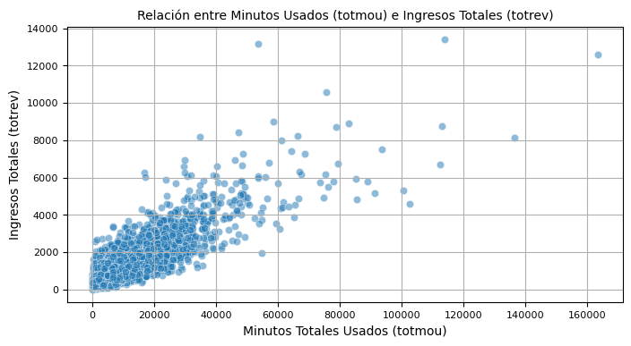

```python
# Relación entre minutos usados y ingresos (scatter plot)
plt.figure(figsize=(8, 4))
sns.scatterplot(x='totmou', y='totrev', data=df_knn, alpha=0.5)
plt.title('Relación entre Minutos Usados (totmou) e Ingresos Totales (totrev)', fontsize=10)
plt.xlabel('Minutos Totales Usados (totmou)', fontsize=10)
plt.ylabel('Ingresos Totales (totrev)', fontsize=10)
plt.xticks(fontsize=8)  # Cambiar el tamaño de las etiquetas en el eje X
plt.yticks(fontsize=8)  # Cambiar el tamaño de las etiquetas en el eje Y
plt.grid(True)
plt.show()
```

#### **⭕️ Conclusión Grafico de Dispersión para describir relación entre Minutos v.s Ingreso de los Clientes**

El gráfico de dispersión muestra una concentración significativa de datos, la mayoría de los datos se agrupan cerca del origen, lo que sugiere que muchos clientes tienen tanto un bajo uso de minutos como ingresos bajos. Esto puede ser indicativo de un segmento de clientes menos activos o con menor compromiso con el servicio. Tambien se puede argumentar que hay una relación positiva entre las dos variables, porque a medida que el uso de minutos (totmou) aumenta, también lo hace el ingreso (totrev).

#### **📈 Grafico de barras apiladas**

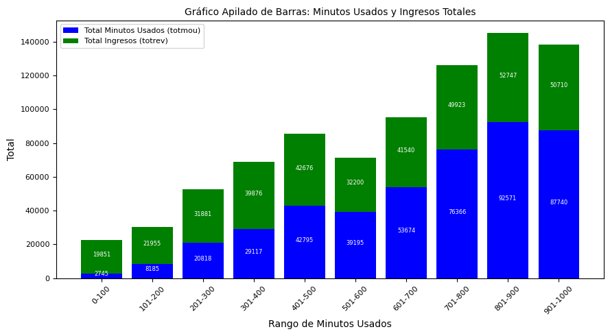

```python
import warnings
import statsmodels.api as sm

# Ignorar advertencias
warnings.filterwarnings("ignore")


# Supongamos que df_knn ya está definido y tiene las columnas 'totmou' y 'totrev'
# Primero, crea bins para totmou
bins = [0, 100, 200, 300, 400, 500, 600, 700, 800, 900, 1000]
labels = ['0-100', '101-200', '201-300', '301-400', '401-500',
          '501-600', '601-700', '701-800', '801-900', '901-1000']

df_knn['totmou_bins'] = pd.cut(df_knn['totmou'], bins=bins, labels=labels)

# Calcular el total para cada bin
totals = df_knn.groupby('totmou_bins')[['totmou', 'totrev']].sum().reset_index()

# Crear gráfico apilado de barras
plt.figure(figsize=(9, 5))

# Configurar el gráfico apilado
plt.bar(totals['totmou_bins'], totals['totmou'], label='Total Minutos Usados (totmou)', color='blue')
plt.bar(totals['totmou_bins'], totals['totrev'], bottom=totals['totmou'], label='Total Ingresos (totrev)', color='green')

# Añadir títulos y etiquetas
plt.title('Gráfico Apilado de Barras: Minutos Usados y Ingresos Totales', fontsize=10)
plt.xlabel('Rango de Minutos Usados', fontsize=10)
plt.ylabel('Total', fontsize=10)

for i in range(len(totals)):
    plt.text(i, totals['totmou'][i] / 2, f"{totals['totmou'][i]:.0f}", ha='center', fontsize=6, color='white')
    plt.text(i, totals['totmou'][i] + totals['totrev'][i] / 2, f"{totals['totrev'][i]:.0f}", ha='center', fontsize=6, color='white')

plt.xticks(rotation=45, fontsize=8)  # Cambiar el tamaño de las etiquetas en el eje X
plt.yticks(fontsize=8)  # Cambiar el tamaño de las etiquetas en el eje Y

# Mostrar leyenda
plt.legend(fontsize=8)

# Mostrar el gráfico
plt.tight_layout()  # Ajustar el layout
plt.show()

df_knn = df_knn.drop(columns=['totmou_bins'])
```

#### **📈 Grafico de calor**

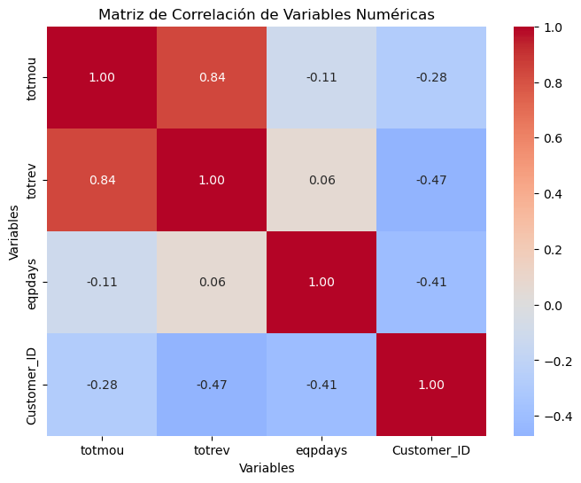

```python
# Gráfica de correlaciones

# Seleccionar solo las columnas numéricas específicas
numerical_cols = df_knn[['totmou', 'totrev', 'eqpdays', 'Customer_ID']]

# Calcular la matriz de correlación
correlation_matrix = numerical_cols.corr()

# Establecer la figura del heatmap
plt.figure(figsize=(8, 6))

# Crear el heatmap
sns.heatmap(correlation_matrix, annot=True, fmt=".2f", cmap='coolwarm', center=0)

# Títulos y etiquetas
plt.title('Matriz de Correlación de Variables Numéricas', fontsize=12)
plt.xlabel('Variables', fontsize=10)
plt.ylabel('Variables', fontsize=10)

# Mostrar el heatmap
plt.show()
```

#### **⭕️ Conclusión Grafico de Calor para describir relación entre Minutos v.s Ingreso de los Clientes**

- **`totrev`** v.s. **`totmou`**: La correlación entre las variables totrev (ingresos totales) y totmou (minutos totales utilizados por los clientes) es 0.84, lo que indica una fuerte correlación positiva entre ambas variables. Esta relación implica que, a medida que aumenta el uso de minutos por parte de un cliente, los ingresos que genera tienden a incrementarse de manera considerable.

#### **⭕️ Exploratorio General de variables**

La metodología del cuadro se centra en la fase exploratoria del análisis de datos, donde se clasifican las variables en numéricas y categóricas. Para las variables numéricas, se utilizarán histogramas que permitirán observar su distribución y detectar patrones o anomalías. En el caso de la variable categórica, se empleará un diagrama de barras para comparar la frecuencia de las distintas categorías. A través de estas visualizaciones, se buscará identificar tendencias, correlaciones y características relevantes, lo que facilitará la formulación de hipótesis y guiará análisis más profundos en etapas posteriores del estudio.

| Nombre de la Variable | Tipo de Variable | Tipo de Gráfico |
| --- | --- | --- |
| `totmou` | Numérica | Histograma |
| `totrev` | Numérica | Histograma |
| `creditcd` | Categórica | Diagrama de Barras |
| `eqpdays` | Numérica | Histograma |
| `Customer_ID` | Numérica | Histograma |

#### **⭕️ Exploratorio de variables númericas**

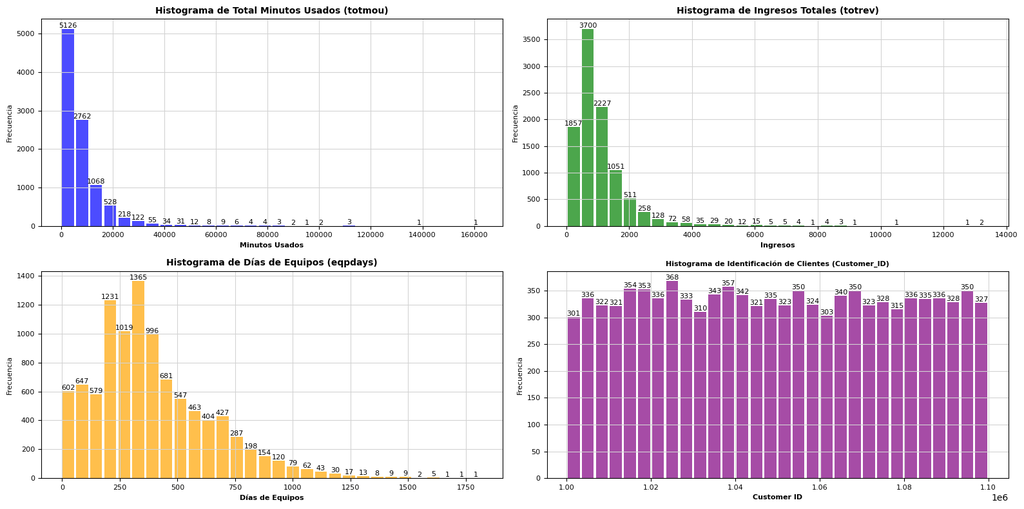

```python
# Crear la figura y los ejes en dos filas
fig, axs = plt.subplots(2, 2, figsize=(16, 8))

# Histograma de totmou
n1, bins1, patches1 = axs[0, 0].hist(df_knn['totmou'], bins=30, color='blue', alpha=0.7, rwidth=0.85)
axs[0, 0].set_title('Histograma de Total Minutos Usados (totmou)', fontsize=10, fontweight='bold')
axs[0, 0].set_xlabel('Minutos Usados', fontsize=8, fontweight='bold')
axs[0, 0].set_ylabel('Frecuencia', fontsize=8)
axs[0, 0].tick_params(axis='both', labelsize=8)
axs[0, 0].grid(True, color='lightgray')  # Colocar la cuadricula

# Añadir los valores encima de las barras para totmou
for i in range(len(patches1)):
    height = patches1[i].get_height()
    if height > 0:
        axs[0, 0].text(patches1[i].get_x() + patches1[i].get_width() / 2, height,
                       int(height), ha='center', va='bottom', fontsize=8)

# Histograma de totrev
n2, bins2, patches2 = axs[0, 1].hist(df_knn['totrev'], bins=30, color='green', alpha=0.7, rwidth=0.85)
axs[0, 1].set_title('Histograma de Ingresos Totales (totrev)', fontsize=10, fontweight='bold')
axs[0, 1].set_xlabel('Ingresos', fontsize=8, fontweight='bold')
axs[0, 1].set_ylabel('Frecuencia', fontsize=8)
axs[0, 1].tick_params(axis='both', labelsize=8)
axs[0, 1].grid(True, color='lightgray')  # Colocar la cuadricula

# Añadir los valores encima de las barras para totrev
for i in range(len(patches2)):
    height = patches2[i].get_height()
    if height > 0:
        axs[0, 1].text(patches2[i].get_x() + patches2[i].get_width() / 2, height,
                       int(height), ha='center', va='bottom', fontsize=8)

# Histograma de eqpdays
n3, bins3, patches3 = axs[1, 0].hist(df_knn['eqpdays'], bins=30, color='orange', alpha=0.7, rwidth=0.85)
axs[1, 0].set_title('Histograma de Días de Equipos (eqpdays)', fontsize=10, fontweight='bold')
axs[1, 0].set_xlabel('Días de Equipos', fontsize=8, fontweight='bold')
axs[1, 0].set_ylabel('Frecuencia', fontsize=8)
axs[1, 0].tick_params(axis='both', labelsize=8)
axs[1, 0].grid(True, color='lightgray')  # Colocar la cuadricula

# Añadir los valores encima de las barras para eqpdays
for i in range(len(patches3)):
    height = patches3[i].get_height()
    if height > 0:
        axs[1, 0].text(patches3[i].get_x() + patches3[i].get_width() / 2, height,
                       int(height), ha='center', va='bottom', fontsize=8)

# Histograma de Customer_ID
axs[1, 1].grid(True, color='lightgray')  # Colocar la cuadricula primero
n4, bins4, patches4 = axs[1, 1].hist(df_knn['Customer_ID'], bins=30, color='purple', alpha=0.7, rwidth=0.85)
axs[1, 1].set_title('Histograma de Identificación de Clientes (Customer_ID)', fontsize=8, fontweight='bold')
axs[1, 1].set_xlabel('Customer ID', fontsize=8, fontweight='bold')
axs[1, 1].set_ylabel('Frecuencia', fontsize=8)
axs[1, 1].tick_params(axis='both', labelsize=8)
axs[1, 1].grid(True, color='lightgray')  # Colocar la cuadricula

# Añadir los valores encima de las barras para Customer_ID
for i in range(len(patches4)):
    height = patches4[i].get_height()
    if height > 0:
        axs[1, 1].text(patches4[i].get_x() + patches4[i].get_width() / 2, height,
                       int(height), ha='center', va='bottom', fontsize=8)

# Ajustar el layout para evitar solapamientos
plt.tight_layout()

# Mostrar la figura
plt.show()
```

#### **⭕️ Conclusión de Exploratorio de variables númericas**

| Variable | Frecuencia Máxima | Tipo de Histograma |
| --- | --- | --- |
| Minutos Usados (totmou) | 5126 | Derecha sesgada |
| Ingresos Totales (totrev) | 3700 | Derecha sesgada |
| Días de Equipos (eqpdays) | 1365 | Derecha sesgada |
| Identificación de Clientes (Customer_ID) | 368 | Meseta (aplanada) |

#### **⭕️ Exploratorio de variables Categoricas**

```
Valores de variable creditcd: [1 0]
creditcd
1    6948
0    3052
Name: count, dtype: int64
```

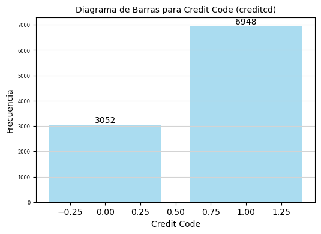

```python
# Contar las ocurrencias de cada categoría en creditcd
creditcd_counts = df_knn['creditcd'].value_counts()

print(f'Valores de variable creditcd: {df_knn['creditcd'].unique()}')
print(creditcd_counts)

# Crear el diagrama de barras
plt.figure(figsize=(6, 4))
bars = plt.bar(creditcd_counts.index, creditcd_counts.values, color='skyblue', alpha=0.7)

# Configurar el título y las etiquetas con tamaño de fuente 10
plt.title('Diagrama de Barras para Credit Code (creditcd)', fontsize=10)
plt.xlabel('Credit Code', fontsize=10)
plt.ylabel('Frecuencia', fontsize=10)

# Mostrar la cuadrícula en gris claro
plt.grid(axis='y', color='lightgray')

# Mostrar los valores encima de las barras
for bar in bars:
    yval = bar.get_height()
    plt.text(bar.get_x() + bar.get_width() / 2, yval, int(yval), ha='center', va='bottom', fontsize=10)

# Mostrar el gráfico
plt.xticks(rotation=0, fontsize=10)  # Mantener las etiquetas del eje x horizontales y tamaño de fuente 10
plt.yticks(fontsize=6)  # Tamaño de fuente para el eje y

# Mostrar el gráfico
plt.show()
```

#### **⭕️ Conclusión de Exploratorio de variables categoricas**

La gráfica de barras muestra que el 69.48% de los clientes (6948) tienen tarjetas de crédito (categoría 1), mientras que el 30.52% (3052) no las poseen (categoría 0). Esta distribución sugiere una sólida base de clientes con acceso a crédito, lo que podría ser una oportunidad para la empresa para desarrollar productos y estrategias de marketing dirigidos a este segmento mayoritario, optimizando la oferta de servicios financieros.

#### **⭕️ Graficos para describir relación entre Minutos v.s Ingreso de los Clientes**

```
                            OLS Regression Results
==============================================================================
Dep. Variable:                 totrev   R-squared:                       0.698
Model:                            OLS   Adj. R-squared:                  0.698
Method:                 Least Squares   F-statistic:                 2.311e+04
Date:                Sat, 26 Oct 2024   Prob (F-statistic):               0.00
Time:                        11:03:05   Log-Likelihood:                -75738.
No. Observations:               10000   AIC:                         1.515e+05
Df Residuals:                    9998   BIC:                         1.515e+05
Df Model:                           1
Covariance Type:            nonrobust
==============================================================================
                 coef    std err          t      P>|t|      [0.025      0.975]
------------------------------------------------------------------------------
const        405.8308      6.301     64.405      0.000     393.479     418.183
totmou         0.0827      0.001    152.025      0.000       0.082       0.084
==============================================================================
Omnibus:                     5006.586   Durbin-Watson:                   2.012
Prob(Omnibus):                  0.000   Jarque-Bera (JB):           176283.068
Skew:                           1.764   Prob(JB):                         0.00
Kurtosis:                      23.264   Cond. No.                     1.55e+04
==============================================================================

Notes:
[1] Standard Errors assume that the covariance matrix of the errors is correctly specified.
[2] The condition number is large, 1.55e+04. This might indicate that there are
strong multicollinearity or other numerical problems.
Intercepto (α): 405.83
Pendiente (β): 0.08
```

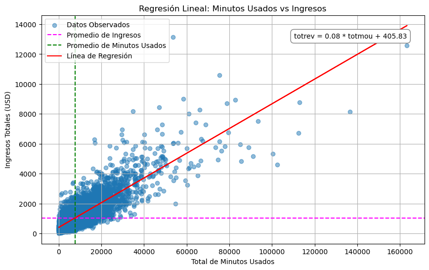

```
Minutos usados: 0 minutos, Ingresos: 405.83
Minutos usados: 100 minutos, Ingresos: 414.10
Minutos usados: 200 minutos, Ingresos: 422.37
Minutos usados: 300 minutos, Ingresos: 430.65
Minutos usados: 400 minutos, Ingresos: 438.92
Minutos usados: 500 minutos, Ingresos: 447.19
Minutos usados: 600 minutos, Ingresos: 455.46
Minutos usados: 700 minutos, Ingresos: 463.73
Minutos usados: 800 minutos, Ingresos: 472.00
Minutos usados: 900 minutos, Ingresos: 480.27
Minutos usados: 1000 minutos, Ingresos: 488.54
```

```python
# Seleccionar las columnas relevantes
X = df_knn['totmou']  # Variable independiente (total de minutos usados)
y = df_knn['totrev']  # Variable dependiente (ingresos)

# Agregar una constante a la variable independiente para el término de intercepto
X = sm.add_constant(X)

# Ajustar el modelo de regresión lineal
model = sm.OLS(y, X).fit()

# Resumen de los resultados del modelo
print(model.summary())

# Extraer los parámetros estimados utilizando .iloc
intercept = model.params.iloc[0]  # α (intercepto)
slope = model.params.iloc[1]  # β (pendiente)

# Mostrar los parámetros estimados
print(f'Intercepto (α): {intercept:.2f}')
print(f'Pendiente (β): {slope:.2f}')

# Visualizar la relación con la línea de regresión
# Gráfico con línea de regresión, medias y etiquetas de la función
plt.figure(figsize=(10, 6))

# Gráfico de dispersión
plt.scatter(df_knn['totmou'], df_knn['totrev'], alpha=0.5, label='Datos Observados')

# Título y ejes
plt.title('Regresión Lineal: Minutos Usados vs Ingresos')
plt.xlabel('Total de Minutos Usados')
plt.ylabel('Ingresos Totales (USD)')

# Líneas de promedio
plt.axhline(y=df_knn['totrev'].mean(), color='magenta', linestyle='--', label='Promedio de Ingresos')
plt.axvline(x=df_knn['totmou'].mean(), color='g', linestyle='--', label='Promedio de Minutos Usados')

# Línea de regresión
plt.plot(df_knn['totmou'], intercept + slope * df_knn['totmou'], color='red', label='Línea de Regresión')

# Mostrar la ecuación en la parte superior derecha del gráfico
equation_text = f'totrev = {slope:.2f} * totmou + {intercept:.2f}'
plt.text(df_knn['totmou'].max(), df_knn['totrev'].max(), equation_text, fontsize=10, color='black',
         verticalalignment='top', horizontalalignment='right',
         bbox=dict(facecolor='white', edgecolor='gray', boxstyle='round,pad=0.5'))

# Leyenda y cuadrícula
plt.legend(loc='upper left')
plt.grid()

# Mostrar gráfico
plt.show()

# Definición de la función de regresión
def predict_totrev(totmou):
    return slope * totmou + intercept

# Ejemplo de uso de la función predict_totrev
# Calcular los ingresos para diferentes valores de minutos usados
minutos_usados = []
for i in range(0, 1001, 100):  # De 100 a 1000 minutos en incrementos de 100
    minutos_usados.append(i)
ingresos = [predict_totrev(totmou) for totmou in minutos_usados]

# Imprimir los resultados
for totmou, rev in zip(minutos_usados, ingresos):
    print(f"Minutos usados: {totmou} minutos, Ingresos: {rev:.2f}")
```

#### **⭕️ Conclusión relación entre Minutos v.s Ingreso de los Clientes**

El modelo de regresión lineal muestra que existe una relación positiva significativa entre los minutos utilizados por los clientes (`totmou`) y los ingresos totales generados (`totrev`). El R-cuadrado de `0.698` indica que el `69.8%` de la variabilidad en los ingresos puede explicarse por los minutos usados. La pendiente `(β = 0.08)` sugiere que, por cada minuto adicional usado, los ingresos aumentan en promedio en `0.08` unidades. El intercepto (`α = 405.83`) representa los ingresos estimados cuando los minutos utilizados son cero.

El gráfico de dispersión muestra una concentración significativa de datos alrededor del punto de intersección entre las líneas de promedio de ingresos, promedio de minutos utilizados y la línea de regresión totrev = 0.08 * totmou + 405.83, lo que indica que la mayoría de los clientes se sitúan cerca de estos valores medios. A medida que aumenta la pendiente de la línea de regresión, algunos datos se dispersan, reflejando que, aunque existe una clara relación positiva entre los minutos usados y los ingresos, no todos los clientes siguen esta tendencia de manera uniforme, sugiriendo la influencia de otros factores en algunos casos.

#### **⭕️¿Existe relación alguna entre el total de minutos usados con la compañía y el ingreso total de los clientes?**

Sí, existe una relación significativa entre el total de minutos utilizados por los clientes (totmou) y el ingreso total generado (totrev). El modelo de regresión lineal indica que aproximadamente el 69.8% de la variabilidad en los ingresos puede explicarse por la cantidad de minutos usados. Además, se establece que por cada minuto adicional utilizado, los ingresos aumentan en promedio en 0.08 unidades. Sin embargo, aunque hay una tendencia clara, el gráfico de dispersión muestra que no todos los clientes siguen esta relación de manera uniforme, lo que sugiere que otros factores también pueden influir en los ingresos

#### **⭕️ Analisis de correlación entre variables `creditcd` , `totrev` y `totmou` (Diagrama de Dispersión)**

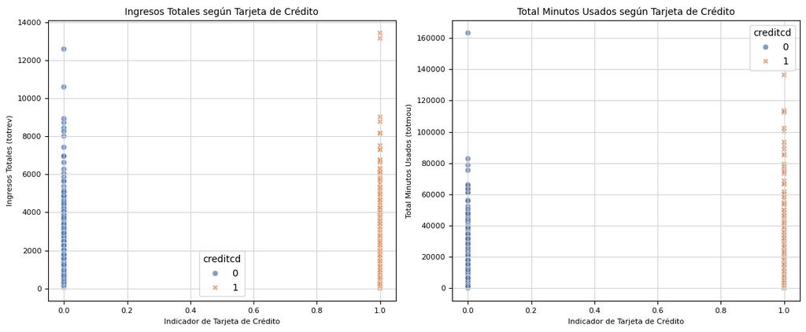

```python
# Crear una figura con dos subgráficas
fig, axs = plt.subplots(1, 2, figsize=(12, 5))

# Gráfico de dispersión: creditcd vs totrev
sns.scatterplot(x='creditcd', y='totrev', data=df_knn, ax=axs[0], hue='creditcd', style='creditcd', palette='deep', alpha=0.7)
axs[0].set_title('Ingresos Totales según Tarjeta de Crédito', fontsize=10)
axs[0].set_xlabel('Indicador de Tarjeta de Crédito', fontsize=8)
axs[0].set_ylabel('Ingresos Totales (totrev)', fontsize=8)
axs[0].grid(color='lightgray')
axs[0].tick_params(axis='both', labelsize=8)

# Gráfico de dispersión: creditcd vs totmou
sns.scatterplot(x='creditcd', y='totmou', data=df_knn, ax=axs[1], hue='creditcd', style='creditcd', palette='deep', alpha=0.7)
axs[1].set_title('Total Minutos Usados según Tarjeta de Crédito', fontsize=10)
axs[1].set_xlabel('Indicador de Tarjeta de Crédito', fontsize=8)
axs[1].set_ylabel('Total Minutos Usados (totmou)', fontsize=8)
axs[1].grid(color='lightgray')
axs[1].tick_params(axis='both', labelsize=8)

# Ajustar el layout
plt.tight_layout()
plt.show()
```